# Assignment 3

Wenjun Sun

2020/4/8

This project analyzes the descriptions of kickstarter projects to identify commonalities of successful (and unsuccessful projects) using text mining techniques.

Data for this project comes from [webroboto.io’s repository](https://webrobots.io/kickstarter-datasets/), which crawls all Kickstarter projects monthly since 2019.

```r
projects <- read.csv("data\\kickstarter_projects_2020_02.csv", stringsAsFactors = F, encoding = "UTF-8")
```

# Text Mining Kickstarter Projects

## Identifying Successful Projects

### Success by Category

The metric I choose to identify success of a project is **state**, which has five values: successful, live, failed, canceled, suspended. For this part, I created a binnary variable *successful/unsuccessful* to evaluate the success of a project. Failed, canceled, and suspended projects are combined into one catgory - “unsuccessful” and live projects are excluded.

```r
projects <- projects %>%
  # remove duplicates
  select(-source_url) %>%
  unique() %>%
  # remove projects with no category info
  filter(top_category != "")

category_list <- projects %>%
  group_by(top_category) %>%
  summarise(cnt = n()) %>%
  ungroup() %>%
  filter(cnt > 1000) %>%
  pull(top_category)

projects <- projects %>%
  # remove projects with an uncommon category (less than 1000 projects)
  filter(top_category %in% category_list) %>%
  # calculate achievement ratio
  mutate(achievement_ratio = as.numeric(pledged)/as.numeric(goal)*100)
```

```r
# for dumbbell plot
category_success <-
  projects %>%
  filter(state != "live") %>%
  mutate(state = case_when(
    state %in% c("failed", "canceled", "suspended") ~ "unsuccessful",
    TRUE ~ "successful"
  )) %>%
  group_by(top_category, state) %>%
  summarise(cnt = n()) %>%
  ungroup() %>%
  add_row(top_category = "", state = "successful", cnt = NA) %>%
  add_row(top_category = "  ", state = "successful", cnt = NA) %>%
  mutate(top_category=factor(top_category,
                             levels = rev(c("  ","music","publishing","film & video","art","comics","games","fashion","design","dance","theater","", "technology","food","crafts","photography","journalism")))) %>%
  mutate(state = factor(state, levels = c("unsuccessful", "successful"))) %>%
  pivot_wider(names_from = state, values_from = cnt)
```

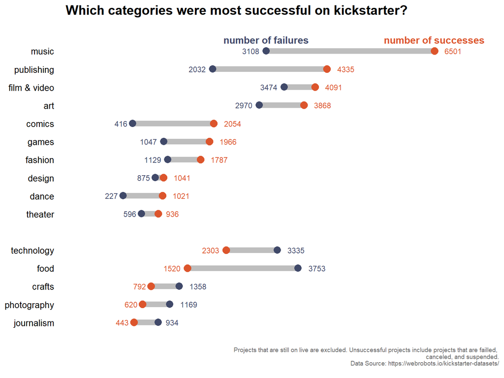

```r
library(ggalt)

ggplot(category_success, aes(y = top_category, x = unsuccessful, xend = successful)) +
  geom_dumbbell(size = 3, color = "grey",
                colour_x = "#404969",
                colour_xend = "#dc552c",
                dot_guide = FALSE) +
  # text label of dots
  geom_text(data = category_success %>% filter(top_category == "music"),
            aes(x = unsuccessful, y = top_category, label = "number of failures"),
            color="#404969", size = 4, vjust = -1,
            fontface = "bold") +
  geom_text(data = category_success %>% filter(top_category == "music"),
            aes(x = successful, y = top_category, label = "number of successes"),
            color = "#dc552c", size = 4, vjust = -1,
            fontface = "bold") +
  # numeric label of dots
  geom_text(data = category_success %>% filter(unsuccessful < successful),
            aes(x = unsuccessful, y = top_category, label = unsuccessful),
            color = "#404969", size = 3,
            hjust = 1.4) +
  geom_text(data = category_success %>% filter(unsuccessful > successful),
            aes(x = successful, y = top_category, label = successful),
            color = "#dc552c", size = 3,
            hjust = 1.4) +
  geom_text(data = category_success %>% filter(unsuccessful < successful),
            aes(x = successful, y = top_category, label = successful),
            color = "#dc552c", size = 3,
            hjust = -0.6) +
  geom_text(data = category_success %>% filter(unsuccessful > successful),
            aes(x = unsuccessful, y = top_category, label = unsuccessful),
            color = "#404969", size = 3,
            hjust = -0.6) +

  scale_x_continuous(expand = c(0, 1300)) +

  labs(
    title = "  Which categories were most successful on kickstarter?",
    caption = "
    Projects that are still on live are excluded. Unsuccessful projects include projects that are failled,
    canceled, and suspended.
    Data Source: https://webrobots.io/kickstarter-datasets/
    "
  ) +

  theme_hc() +

  theme(
    panel.grid.major.y = element_blank(),
    axis.ticks = element_blank(),
    axis.text.x = element_blank(),
    axis.text.y = element_text(color = "black", size = 10),
    axis.title.x = element_blank(),
    axis.title.y = element_blank(),


    legend.position = "none",

    plot.title = element_text(size = 15, face = "bold"),
    plot.caption=element_text(size=7, color="grey40"),
  )
```

From the plot above, we can see that most categories have more successful projects than unsuccessful projects - music, publishing, film & video, and art are four categories that have the most successful projects. On the other hand, some categories like technology, food, crafts, photography, and journalism have more failed projects than successful ones.

### Success by Location

Calculate the total number of successful projects by state (also normalize by population). Apart from that, identify the Top 50 “innovative” cities in the U.S. (by total number of successful projects).

Provide a leaflet map showing the most innovative states and cities in the U.S. on a single map based on these information.

```r
library(openintro)
library(rvest)

# number of successful projects by state
state_success <- projects %>%
  filter(state == "successful") %>%
  group_by(location_state) %>%
  summarise(n = n()) %>%
  ungroup() %>%
  mutate(location_state = abbr2state(location_state))

# normalized by state population
state_population <- "https://en.wikipedia.org/wiki/List_of_U.S._states_and_territories_by_population" %>%
  xml2::read_html() %>%
  html_node("table") %>%
  html_table(fill = TRUE)
state_population <- state_population[, 3:4]

state_population <- state_population %>%
  slice(2:n()) %>%
  select(state = State, population = "Census population") %>%
  mutate(population = as.numeric(gsub(",","",population))) %>%
  left_join(state_success, by = c("state"="location_state")) %>%
  drop_na() %>%
  mutate(project.per.capita = n/population*1000000) # number of successful projects per million people
```

```r
library(ggmap)
city_success <- projects %>%
  filter(state == "successful") %>%
  mutate(location_town = case_when(location_town == "Brooklyn" ~ "New York",
                                   location_town == "Manhattan" ~ "New York",
                                   location_town == "Hollywood" ~ "Los Angeles",
                                   TRUE ~ location_town)) %>%
  mutate(location_state = abbr2state(location_state)) %>%
  group_by(location_state, location_town) %>%
  summarise(n = n()) %>%
  ungroup() %>%
  top_n(50, wt = n) %>%
  mutate_geocode(location_town, output = "more")

write.csv(city_success, "data\\city_success.csv")
```

```r
city_success <- read.csv("data\\city_success.csv") %>%
  select(location_state, location_town, n, lon, lat)

# hand-code lon and lat for San Diego
city_success$lon[city_success$location_town == "San Diego"] <- -117.1611
city_success$lat[city_success$location_town == "San Diego"] <- 32.7157
```

```r
library(leaflet)
library(geojsonio)

states <- geojsonio::geojson_read("data/gz_2010_us_040_00_500k.json", what = "sp")
states@data <- states@data %>%
  left_join(state_population, by = c("NAME"="state")) %>%
  replace_na(list(n=0))


bins_absolute <- c(0, 100, 500, 1000, 2000, 5000, Inf)
pal_absolute <- colorBin("Reds", domain = states$n, bins = bins_absolute)

bins_percapita <- c(0, 30, 60, 100, 200, 500, Inf)
pal_percapita <- colorBin("Reds", domain = states$project.per.capita, bins = bins_percapita)

popupPolygons <- sprintf("<strong>%s</strong><br/>%s",
                        states@data$NAME,
                        paste(states@data$n, "successful projects"),
                        paste(states@data$project.per.capita, "successful projects per million people")
                        ) %>%
    lapply(htmltools::HTML)

popupCircle <- sprintf(
  "<strong>%s</strong><br/>%s",
  paste0(city_success$location_town,", ",city_success$location_state),
  paste(city_success$n, "successful projects")
) %>%
  lapply(htmltools::HTML)

leaflet(states, options = leafletOptions(minZoom = 3)) %>%
  addProviderTiles(providers$CartoDB.Positron) %>%
  setView(lng = -99.8421, lat = 39.3647, zoom = 3) %>%
  addPolygons(fillColor = ~pal_absolute(n),
              stroke = FALSE,
              smoothFactor = 0.5,
              fillOpacity = 0.7,
              label = popupPolygons,
              labelOptions = labelOptions(
                style = list("font-weight" = "normal", padding = "3px 8px"),
                textsize = "13px",
                direction = "auto"
                )
              ) %>%
   addCircleMarkers(
    lng = city_success$lon, lat = city_success$lat,
    radius = city_success$n/500,
    color = "#7EC8BA",
    stroke = FALSE, fillOpacity = 1,
    label = popupCircle,
    labelOptions = labelOptions(
      style = list("font-weight" = "normal", padding = "3px 8px"),
      textsize = "13px",
      direction = "auto"
    )
  ) %>%

  addLegend(colors = c("#a50f15","#de2d26","#fb6a4a","#fc9272","#fcbba1","#fee5d9"),
            labels = c(">5000","2000-5000","1000-2000","500-1000","100-500","<100"),
            opacity = 0.7, title = NULL, position = "bottomright") %>%

  addControl("Successful Kickstarter Projects by States and Top 50 Innovative Cities", position = "topright")
```

[interactive chart not shown]

## Success Story

### Cleaning the Text and Word Cloud

Each project contains a blurb – a short description of the project. While not the full description of the project, the short headline is arguably important for inducing interest in the project (and ultimately popularity and success).

To reduce the time for analysis, select the 1000 most successful projects and a sample of 1000 unsuccessful projects. Perform regular text cleaning and remove unqiue brand names (usually in upper cases). Stem the words left over and complete the stems.

Provide a word cloud of the most important words (measured by tf-idf) among the most successful projects.

```r
# add an index column to project dataframe
projects <- projects %>%
  mutate(rowid = row_number())

success1000 <- projects %>%
  filter(!is.na(blurb)) %>%
  top_n(n = 1000, wt = achievement_ratio) %>%
  select(doc_id = rowid, text = blurb)

unsuccess1000 <- projects %>%
  filter(state == "failed" & !is.na(blurb)) %>%
  sample_n(1000) %>%
  select(doc_id = rowid, text = blurb)
```

```r
library(tm)
library(rJava)
library(qdap)
library(SnowballC)

success_source <- DataframeSource(success1000)
success_corpus <- VCorpus(success_source)

myStopWords <- c("d", "will", "get", "can")

clean_corpus <- function(corpus) {
  corpus <- corpus %>%
    tm_map(stripWhitespace) %>%
    tm_map(content_transformer(function(x,pattern) gsub("(?:[A-Z][a-z]+ ){2,}","", x))) %>% # remove brand name
    tm_map(content_transformer(replace_abbreviation)) %>%
    tm_map(content_transformer(replace_contraction)) %>%
    tm_map(content_transformer(replace_symbol)) %>%
    tm_map(removeNumbers) %>%
    tm_map(removePunctuation) %>%
    tm_map(content_transformer(tolower)) %>%
    tm_map(removeWords, c(stopwords("english"), myStopWords)) %>%
    tm_map(stripWhitespace)
  return(corpus)
}

success_corpus <- clean_corpus(success_corpus)

# stem and complete the stems
dictCorpus <- success_corpus
success_corpus <- tm_map(success_corpus, content_transformer(stemDocument))
stemCompletion2 <- function(x, dictionary) {
    x <- unlist(strsplit(as.character(x), " "))
    # Oddly, stemCompletion completes an empty string to
  # a word in dictionary. Remove empty string to avoid issue.
    x <- x[x != ""]
    x <- stemCompletion(x, dictionary=dictionary)
    x <- paste(x, sep="", collapse=" ")
    PlainTextDocument(stripWhitespace(x))
}
success_corpus <- tm_map(success_corpus, content_transformer(stemCompletion2), dictionary = dictCorpus)

save(success_corpus, file = "success_corpus.RData")

# have a peek at the corpus
#peek <- c()
#for(i in 1:length(success_corpus)) {
#  row <- unlist(success_corpus[i])["content.content"]
#  peek <- rbind(peek, row)
#}
#peek
```

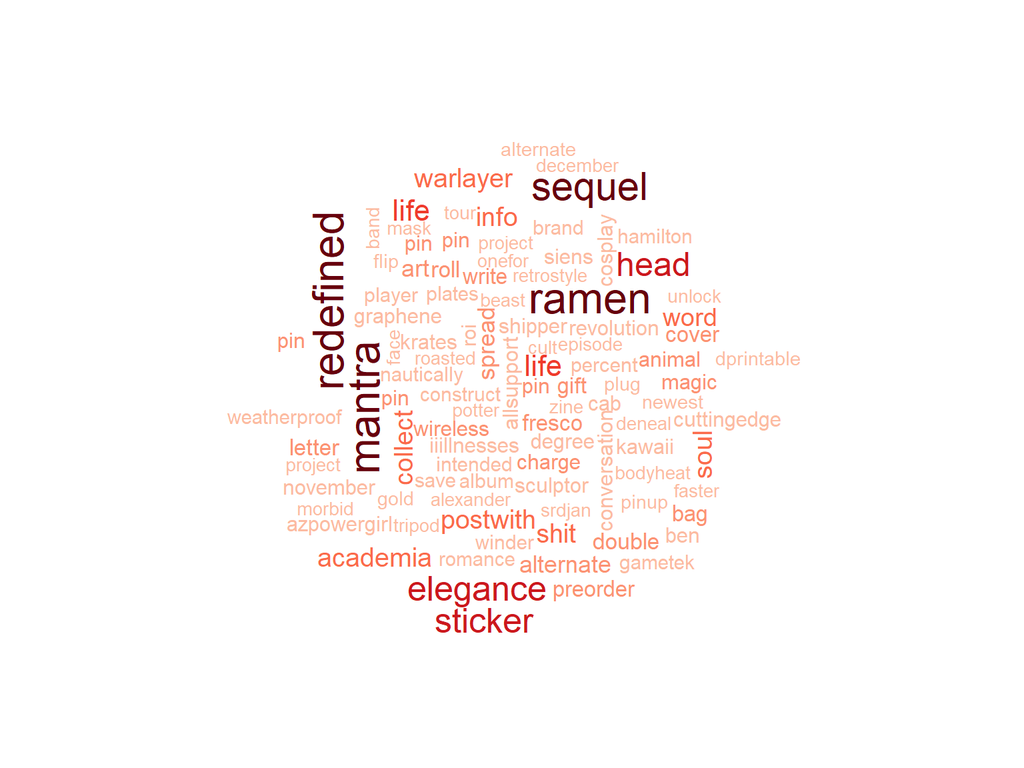

```r
library(tm)
library(tidytext)
library(wordcloud)

load("success_corpus.RData")

# create a document-term-matrix
success_dtm <- tm::DocumentTermMatrix(success_corpus)

success_td <- tidy(success_dtm)

success_tfidf <- success_td %>%
  bind_tf_idf(term, document, count) %>%
  arrange(desc(tf_idf)) %>%
  filter(term != "steve")

# Set seed
set.seed(1997)

wordcloud(success_tfidf$term, success_tfidf$tf_idf, scale = c(2,.5), min.freq = 0,
          max.words = 100,
          colors = brewer.pal(max(9, ncol(success_tfidf$tf_idf)),"Reds"))
```

### Success in words

Provide a pyramid plot to show how the words between successful and unsuccessful projects differ in frequency. For the effciency of graph, use a selection of 10 - 20 top words.

```r
unsuccess_source <- DataframeSource(unsuccess1000)
unsuccess_corpus <- VCorpus(unsuccess_source)

unsuccess_corpus <- clean_corpus(unsuccess_corpus)

unsuccess_corpus <- tm_map(unsuccess_corpus, content_transformer(stemDocument))
dictCorpus_unsuccess <- success_corpus
unsuccess_corpus <- tm_map(unsuccess_corpus, content_transformer(stemCompletion2), dictionary = dictCorpus_unsuccess)

save(unsuccess_corpus, file = "unsuccess_corpus.RData")
```

```r
library(forcats)

load("unsuccess_corpus.RData")
unsuccess_dtm <- DocumentTermMatrix(unsuccess_corpus)
unsuccess_td <- tidy(unsuccess_dtm)

topword_success <- success_td %>%
  group_by(term) %>%
  summarise(n = n()) %>%
  ungroup() %>%
  top_n(30, wt = n)

topword_unsuccess <- unsuccess_td %>%
  group_by(term) %>%
  summarise(n = n()) %>%
  ungroup() %>%
  top_n(30, wt = n)

topword <- left_join(topword_success, topword_unsuccess, by = "term", suffix = c(".success", ".unsuccess")) %>%
  drop_na() %>%
  mutate(term = fct_reorder(term, n.success)) %>%
  pivot_longer(cols = c(n.success, n.unsuccess),names_to = "state", values_to = "n") %>%
  mutate(n_inv = ifelse(state=="n.unsuccess", n*-1, n))
```

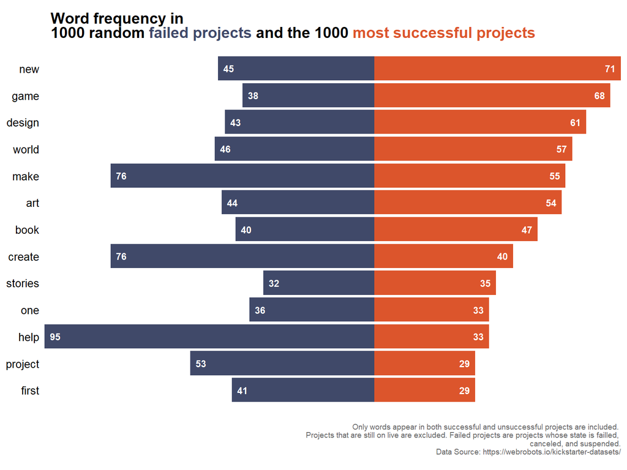

```r
library(ggtext)

ggplot(topword) +
  geom_bar(aes(x = term, y = n_inv, fill = rev(state)),
           stat = "identity", position = "identity") +

  geom_text(data = topword %>% filter(state == "n.success"),
            aes(x = term, y = n_inv, label = n),
            color = "white", fontface = "bold", size = 3, hjust = 1.5) +
  geom_text(data = topword %>% filter(state == "n.unsuccess"),
            aes(x = term, y = n_inv, label = n),
            color = "white", fontface = "bold", size = 3, hjust = -0.5) +
  coord_flip() +

  labs(
    title = "<b><span style = 'font-size:14pt'> Word frequency in <br>1000 random <span style = 'color:#404969;'>**failed projects**</span> and the 1000 <span style = 'color:#dc552c;'>**most successful projects**</span></span></b>",
    caption = "
    Only words appear in both successful and unsuccessful projects are included.
    Projects that are still on live are excluded. Failed projects are projects whose state is failled,
    canceled, and suspended.
    Data Source: https://webrobots.io/kickstarter-datasets/
    "
  ) +

  scale_fill_manual(values = c("#404969","#dc552c")) +
  scale_y_continuous(breaks = seq(-50, 50, 25), expand = c(0, 0)) +

  theme_hc() +

  theme(
    panel.grid.major.y = element_blank(),
    axis.ticks = element_blank(),
    axis.text.x = element_blank(),
    axis.text.y = element_text(color = "black", size = 10),
    axis.title.x = element_blank(),
    axis.title.y = element_blank(),

    legend.position = "none",

    plot.title = element_textbox_simple(
      size = 13,
      lineheight = 1,
      padding = margin(5.5, 5.5, 5.5, 5.5),
      margin = margin(0, 0, 5.5, 0)
    ),
    plot.caption=element_text(size=7, color="grey40"),
  )
```

### Simplicity as a virtue

These blurbs are short in length (max. 150 characters) but let’s see whether brevity and simplicity still matters. Calculate a readability measure (Flesh Kincaid) for the texts. Visualize the relationship between the readability measure and one of the measures of success.

```r
library(quanteda)

df_read <- projects %>%
  filter(!is.na(blurb)) %>%
  select(rowid, blurb, state, top_category) %>%
  filter(state %in% c("successful", "failed"))

read_corpus <- corpus(df_read, docid_field = "rowid", text_field = "blurb")

FRE_projects <- textstat_readability(read_corpus, measure=c('Flesch.Kincaid'))
```

```r
library(scales)
library(ggrepel)

read_category <- FRE_projects %>%
  mutate(document = as.numeric(document)) %>%
  left_join(df_read, by = c("document" = "rowid")) %>%
  group_by(top_category, state) %>%
  summarise(avgFRE = mean(Flesch.Kincaid, na.rm = TRUE)) %>%
  ungroup() %>%
  pivot_wider(names_from = state, values_from = avgFRE) %>%
  mutate(moreReadable = ifelse(successful>failed, "easier", "harder")) %>%
  pivot_longer(cols = c("failed", "successful"), names_to = "state", values_to = "avgFRE") %>%
  mutate(state = ifelse(state == "successful", 1, 0))
```

[figure not shown]

```r
ggplot(read_category, aes(x=state, y=avgFRE, group = top_category, color = moreReadable)) +
  geom_line(alpha=0.7, size = 2) +
  geom_point(alpha=0.7, size = 4) +
  geom_text_repel(data = read_category %>% filter(state == 1 & moreReadable == "harder"),
                  aes(x = state, y = avgFRE, label = top_category),
                  size = 3.5, nudge_x = 0.2) +

  labs(title = "Write a Readable Description!",
       subtitle = "... unless it's about technology, publishing, design, or music.",
       caption = "
       Unlabeled categories are dance, journalism, photography, theater, art, film & video, comics, food, fashion, games, and crafts, respectively.
       Fresch-Kincaid Reading Ease Score is used to measure readability.
       Data Source: https://webrobots.io/kickstarter-datasets/
       "
       ) +

  scale_color_manual(values = c("#dc552c", "grey50")) +

  scale_x_continuous(breaks = c(0, 1), labels = c("failed projects", "successful projects"),
                     expand = expansion(0.8, 0)) +
  scale_y_continuous(breaks = c(8,9,10,11), labels = c("Harder to read\n8", "9", "10", "Easier to read\n11"),
                     expand = expansion(0, 0.5)) +

  theme_hc() +

  theme(
    axis.ticks = element_blank(),
    axis.title.x = element_blank(),
    axis.title.y = element_blank(),
    legend.position = "none",

    plot.caption=element_text(size=7, color="grey40"),
    plot.title = element_text(size = 15, face = "bold")
  )
```

## Sentiment

### Stay positive

Now, let’s check whether the use of positive / negative words or specific emotions helps a project to be successful.

Calculate the tone of each text based on the positive and negative words that are being used. I used the Bing dictionary contained in the tidytext package. Visualize the relationship between tone of the document and success.

```r
library(tidytext)

bing_neg <- get_sentiments("bing") %>%
filter(sentiment == "negative")
bing_pos <- get_sentiments("bing") %>%
filter(sentiment == "positive")

bing_sentiment <- rbind(bing_neg,bing_pos)

success_sen <- projects %>%
  filter(state == "successful" & !is.na(blurb)) %>%
  select(rowid, text = blurb) %>%
  unnest_tokens(word, text) %>%
  left_join(bing_sentiment, by = "word") %>%
  group_by(rowid) %>%
  summarise(total = n(),
            pos_cnt = sum(sentiment == "positive", na.rm = TRUE),
            neg_cnt = sum(sentiment == "negative", na.rm = TRUE)) %>%
  ungroup() %>%
  mutate(tone = (pos_cnt-neg_cnt)/(pos_cnt+neg_cnt)) %>%
  filter(!is.na(tone))

unsuccess_sen <- projects %>%
  filter(state == "failed" & !is.na(blurb)) %>%
  select(rowid, text = blurb) %>%
  unnest_tokens(word, text) %>%
  left_join(bing_sentiment, by = "word") %>%
  group_by(rowid) %>%
  summarise(total = n(),
            pos_cnt = sum(sentiment == "positive", na.rm = TRUE),
            neg_cnt = sum(sentiment == "negative", na.rm = TRUE)) %>%
  ungroup() %>%
  mutate(tone = (pos_cnt-neg_cnt)/(pos_cnt+neg_cnt)) %>%
  filter(!is.na(tone))
```

```r
success_sum <- success_sen %>%
  summarise(sum_pos = sum(pos_cnt), sum_neg = sum(neg_cnt)) %>%
  mutate(type = "successful projects") %>%
  pivot_longer(cols = c("sum_pos", "sum_neg"), names_to = "part")

unsuccess_sum <- unsuccess_sen %>%
  summarise(sum_pos = sum(pos_cnt), sum_neg = sum(neg_cnt)) %>%
  mutate(type = "unsuccessful projects") %>%
  pivot_longer(cols = c("sum_pos", "sum_neg"), names_to = "part")

sen_sum <- rbind(success_sum, unsuccess_sum) %>%
  mutate(type = factor(type, levels = c("successful projects", "unsuccessful projects")))
```

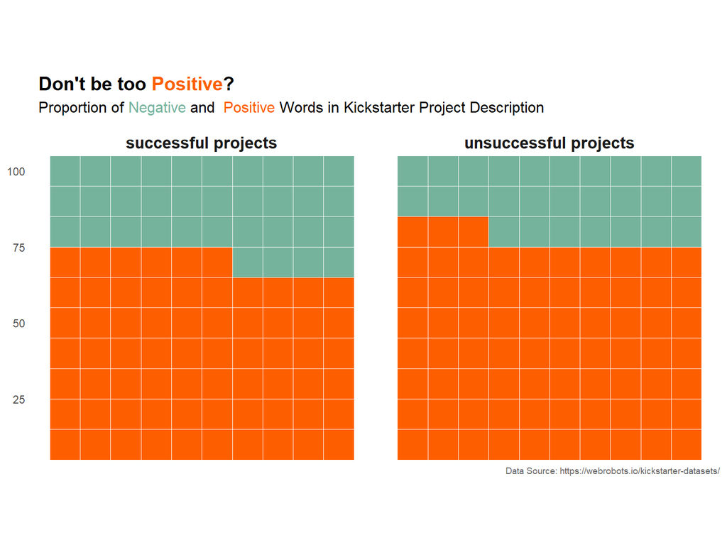

```r
library(waffle)
library(scales)


ggplot(sen_sum, aes(fill = part, values = value)) +
  geom_waffle(color = "white", size = .25, n_rows = 10, flip = TRUE, make_proportional = TRUE) +
  facet_wrap(~type, nrow = 1, strip.position = "top") +

  coord_equal() +

  scale_x_discrete() +
  scale_y_continuous(labels = function(x) x * 10,
                     expand = c(0,0)) +
  scale_fill_manual(values = c("#76b39d", "#fd5f00")) +

  labs(
    title = "<b>Don't be too <span style = 'color:#fd5f00;'>Positive</span>?</b>",
    subtitle = "Proportion of <span style = 'color:#76b39d;'>Negative </span>and <span style = 'color:#fd5f00;'> Positive </span>Words in Kickstarter Project Description",
    caption = "Data Source: https://webrobots.io/kickstarter-datasets/"
  ) +

  theme_minimal(base_family = "Roboto Condensed") +

  theme(
    panel.grid = element_blank(),
    axis.ticks.y = element_blank(),
    strip.text.x = element_text(size = 13, face = "bold"),
    legend.position = "none",

    plot.caption=element_text(size=7, color="grey40"),
    plot.title = element_textbox_simple(
      size = 15,
      lineheight = 1,
      padding = margin(5.5, 5.5, 0, 5.5)
      ),
    plot.subtitle = element_textbox_simple(
      size = 12,
      lineheight = 0.9,
      padding = margin(5.5, 5.5, 5.5, 5.5),
      margin = margin(0, 0, 5.5, 0)
      )
    )
```

From the plot above, it seems that the failed projects use more positive words than successful ones. It’s hard to say if this trait contributes to their failure, but it’s not a bad idea to stay humble when purpose a projects on kickstarter.

### Positive vs negative

Segregate all 2,000 blurbs into positive and negative texts based on their polarity score. Now, collapse the positive and negative texts into two larger documents. Create a document-term-matrix based on this collapsed set of two documents. Generate a comparison cloud showing the most-frequent positive and negative words.

```r
library(stringr)
library(tm)

myStopWords <- c("d", "will", "get", "can")

clean_corpus <- function(corpus) {
  corpus <- corpus %>%
    tm_map(stripWhitespace) %>%
    tm_map(content_transformer(function(x,pattern) gsub("(?:[A-Z][a-z]+ ){2,}","", x))) %>% # remove brand name
    tm_map(content_transformer(replace_abbreviation)) %>%
    tm_map(content_transformer(replace_contraction)) %>%
    tm_map(content_transformer(replace_symbol)) %>%
    tm_map(removeNumbers) %>%
    tm_map(removePunctuation) %>%
    tm_map(content_transformer(tolower)) %>%
    tm_map(removeWords, c(stopwords("english"), myStopWords)) %>%
    tm_map(stripWhitespace)
  return(corpus)
}

merge2000 <- success1000 %>%
  union_all(unsuccess1000) %>%
  unnest_tokens(word, text) %>%
  left_join(bing_sentiment, by = "word") %>%
  group_by(doc_id) %>%
  summarise(total = n(),
            pos_cnt = sum(sentiment == "positive", na.rm = TRUE),
            neg_cnt = sum(sentiment == "negative", na.rm = TRUE)) %>%
  ungroup() %>%
  mutate(tone = (pos_cnt-neg_cnt)/(pos_cnt+neg_cnt)) %>%
  filter(!is.na(tone)) %>%
  mutate(sentiment = ifelse(tone>0, "positive", "negative")) %>%
  left_join(projects, by = c("doc_id"="rowid")) %>%
  mutate(doc_id = ifelse(tone>0, 1, 2)) %>% # doc_id = 1 is positive, 2 is negative
  select(doc_id, text = blurb)

merge2000_source <- DataframeSource(merge2000)
merge2000_corpus <- VCorpus(merge2000_source)
merge2000_corpus <- clean_corpus(merge2000_corpus)
```

```r
dictCorpus <- merge2000_corpus
merge2000_corpus <- tm_map(merge2000_corpus, content_transformer(stemDocument))
merge2000_corpus <- tm_map(merge2000_corpus, content_transformer(stemCompletion2), dictionary = dictCorpus)
save(merge2000_corpus, file = "merge2000_corpus.RData")
```

```r
load("merge2000_corpus.RData")
```

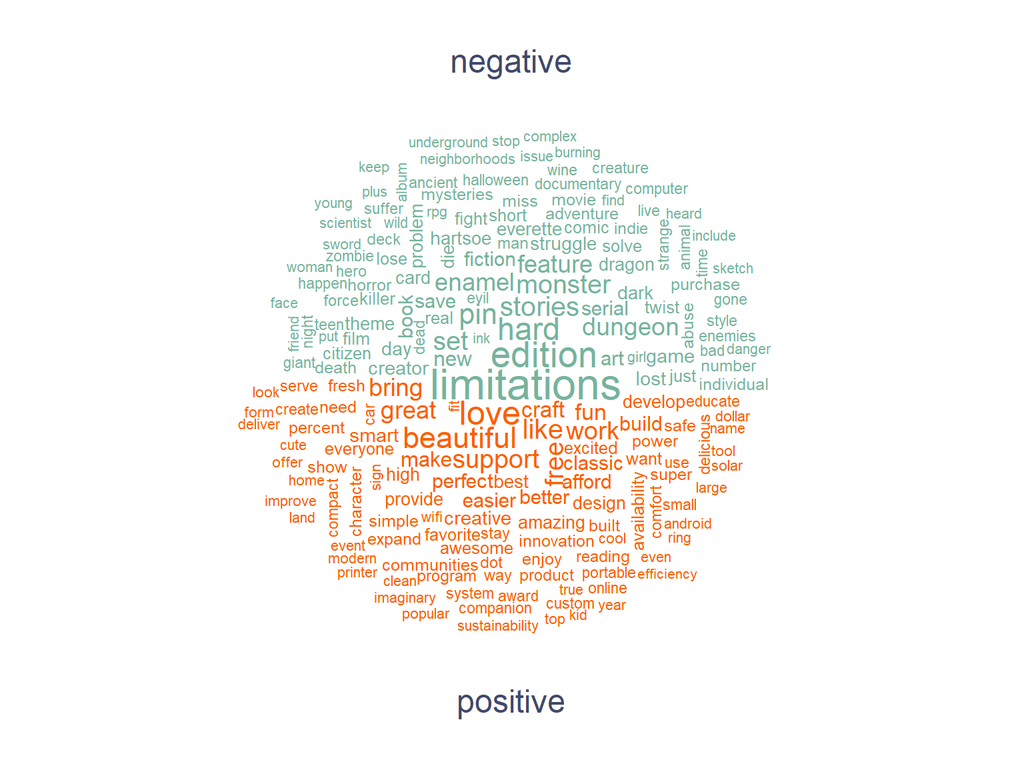

```r
merge_dtm <- DocumentTermMatrix(merge2000_corpus) %>%
  tidy() %>%
  mutate(document = ifelse(document==1, "positive", "negative")) %>%
  group_by(document, term) %>%
  summarise(cnt = sum(count)) %>%
  pivot_wider(names_from = document, values_from = cnt) %>%
  replace_na(list(negative = 0, positive = 0)) %>%
  column_to_rownames(., var = "term")

set.seed(1997)
comparison.cloud(merge_dtm,
                 scale = c(2,.5), max.words = 200,
                 colors = c("#76b39d","#fd5f00"),
                 title.size = 1.5,
                 title.bg.colors = "white", title.colors = "#404969")
```

### Get in their mind

Now, use the NRC Word-Emotion Association Lexicon in the tidytext package to identify a larger set of emotions (anger, anticipation, disgust, fear, joy, sadness, surprise, trust). Again, visualize the relationship between the use of words from these categories and success.

```r
#install.packages("textdata")
library(textdata)

nrc <- get_sentiments("nrc")

success_emo <- projects %>%
  filter(state == "successful" & !is.na(blurb)) %>%
  select(rowid, text = blurb) %>%
  unnest_tokens(word, text) %>%
  left_join(nrc, by = "word") %>%
  replace_na(list(sentiment = "unknown")) %>%
  group_by(sentiment) %>%
  summarise(cnt = n()) %>%
  ungroup() %>%
  mutate(proportion = cnt/sum(cnt)*100) %>%
  select(sentiment, proportion) %>%
  pivot_wider(names_from = sentiment, values_from = proportion) #%>%
  #mutate(label = "successful") %>%
  #select(label, everything())

rownames(success_emo)[1]<-"successful"

failed_emo <- projects %>%
  filter(state == "failed" & !is.na(blurb)) %>%
  select(rowid, text = blurb) %>%
  unnest_tokens(word, text) %>%
  left_join(nrc, by = "word") %>%
  replace_na(list(sentiment = "unknown")) %>%
  group_by(sentiment) %>%
  summarise(cnt = n()) %>%
  ungroup() %>%
  mutate(proportion = cnt/sum(cnt)*100) %>%
  select(sentiment, proportion) %>%
  pivot_wider(names_from = sentiment, values_from = proportion) #%>%
  #mutate(label = "failed") %>%
  #select(label, everything())

rownames(failed_emo)[1] <- "failed"

r_max <- as.data.frame(matrix(8, 1, 11))
r_min <- as.data.frame(matrix(0, 1, 11))
colnames(r_max) <- colnames(failed_emo)
colnames(r_min) <- colnames(failed_emo)
rownames(r_max) <- c("max")
rownames(r_min) <- c("min")

emo_compare <- rbind(r_max, r_min, success_emo, failed_emo) %>%
  select(trust, surprise, positive, joy, anticipation)
```

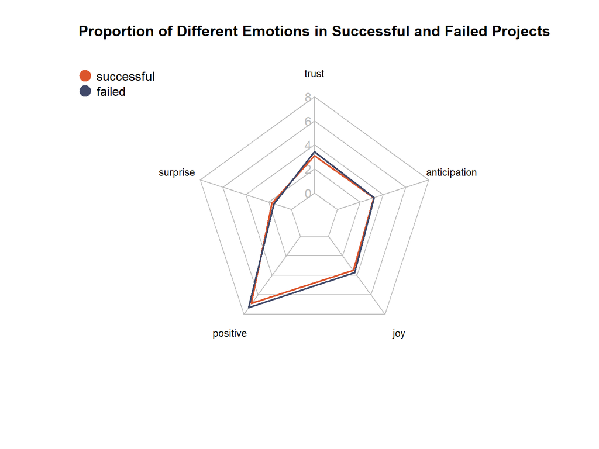

```r
library(fmsb)
radarchart(emo_compare,
           pty = 32, pcol = c("#dc552c","#404969"), plty = 1, plwd = 2,
           cglty=1,  cglwd = 1, cglcol="grey",
           axislabcol="grey",
           title = "Proportion of Different Emotions in Successful and Failed Projects",
           axistype = 1,

           caxislabels=seq(0,8,2),
           vlcex=0.8)
legend(x=-2, y=1.3,
       legend = rownames(emo_compare[-c(1,2),]),
       bty = "n", pch=20 , col=c("#dc552c","#404969") , cex=1, pt.cex=3)
```

I used a radar chart to show the proportion of different positive emotion words in successful and failed projects. I found that they have pretty similar proportion.

In terms of choice of visualization, although I used radar chart for this question, I think there are better options, like dumbbell chart (like in Q1). I found radar a bit too compact and it’s hard to tell the difference when lines are close to each other.